# Functional Enrichment Report (KO_vs_WT)

[figure not shown]

[figure not shown]

[figure not shown]

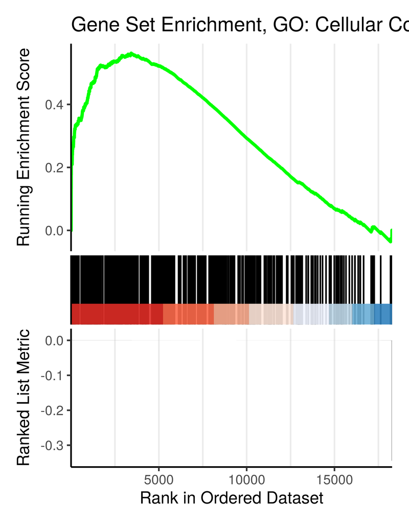

[figure not shown]

# Outline

Functional enrichment analysis was performed with [`clusterProfiler`](https://doi.org/doi:10.18129/B9.bioc.clusterProfiler) (Yu et al. 2012, 2014)

Only genes with a coverage of 10 or more reads in 6 or more samples were included.

This package implements Over representation analysis (Boyle et al. 2004) using the hypergeometric test with a p-value cutoff of 0.05. Genes were considered differentially expressed if they had an FDR < 0.05 in the `DESseq2` model.

As well as Gene Set Enrichment Analysis (Subramanian et al. 2005) using the [`fgsea`](https://doi.org/doi:10.18129/B9.bioc.fgsea) algorithm (Korotkevich et al. 2016), p-value cutoff of 0.05 by permutation for genes rank ordered by log2 fold change.

Adjusted p-values use the Benjamini-Hochberg procedure.

Gene Ratio = k/n (n) The number of genes associated with a given functional annotation e.g. a GO term. (k) The number of these genes found to be of interest in the dataset under examination.

# GSEA

## Plots

**GO Biological Processes**

### Data Table

| ID | Description | n | setSize | percent | enrichmentScore | NES | pvalue | p.adjust | qvalues | rank |
| --- | --- | --- | --- | --- | --- | --- | --- | --- | --- | --- |
| GO:0002250 | adaptive immune response | 137 | 446 | 30.7174887892377 | 0.611976130357118 | 2.36891208003039 | 3.13247837346619e-08 | 0.000171432474770446 | 0.000152163270982169 | 2383 |
| GO:0002443 | leukocyte mediated immunity | 122 | 408 | 29.9019607843137 | 0.618062708999031 | 2.3694768336998 | 5.71251165512984e-08 | 0.000171432474770446 | 0.000152163270982169 | 2270 |
| GO:0002449 | lymphocyte mediated immunity | 99 | 323 | 30.6501547987616 | 0.653891365478878 | 2.46745982654742 | 3.99684442375258e-07 | 0.000799635341045432 | 0.000709755425565326 | 2270 |
| GO:0002460 | adaptive immune response based on somatic recombination of immune receptors built from immunoglobulin superfamily domains | 106 | 348 | 30.4597701149425 | 0.628280762021303 | 2.38379470766228 | 3.32288826457429e-06 | 0.00498599384099372 | 0.00442556250184486 | 2383 |
| GO:0050906 | detection of stimulus involved in sensory perception | 4 | 66 | 6.06060606060606 | 0.842592221425171 | 2.67389520050147 | 2.09509623466481e-05 | 0.0218831935289127 | 0.019423497860332 | 326 |
| GO:0001909 | leukocyte mediated cytotoxicity | 47 | 111 | 42.3423423423423 | 0.756850805416194 | 2.56885887496074 | 2.18759015617254e-05 | 0.0218831935289127 | 0.019423497860332 | 2270 |
| GO:0009581 | detection of external stimulus | 2 | 82 | 2.4390243902439 | 0.803738724810354 | 2.62355145145777 | 2.9271792254357e-05 | 0.0250984710158073 | 0.0222773745262107 | 34 |

### GSEA plot

[figure not shown]

### Dotplot

[figure not shown]

### Network

[figure not shown]

## Plots

**GO Cellular Component**

### Data Table

| ID | Description | n | setSize | percent | enrichmentScore | NES | pvalue | p.adjust | qvalues | rank |
| --- | --- | --- | --- | --- | --- | --- | --- | --- | --- | --- |
| GO:0009897 | external side of plasma membrane | 160 | 430 | 37.2093023255814 | 0.562839807069833 | 2.15396597049884 | 4.84022798588344e-05 | 0.0343172164199136 | 0.0291432674518455 | 3427 |

### GSEA plot

[figure not shown]

### Dotplot

[figure not shown]

### Network

```
[1] "Insufficient data for plot"
```

## Plots

**GO Molecular Function**

### Data Table

```
[1] "No results"
```

### GSEA plot

```
[1] "Insufficient data for plot"
```

### Dotplot

```
[1] "Insufficient data for plot"
```

### Network

```
[1] "Insufficient data for plot"
```

# ORA Up

## Plots

**GO Biological Processes**

### Data Table

```
[1] "No results"
```

### Dotplot

```
[1] "Insufficient data for plot"
```

### Network

```
[1] "Insufficient data for plot"
```

## Plots

**GO Cellular Component**

### Data Table

```
[1] "No results"
```

### Dotplot

```
[1] "Insufficient data for plot"
```

### Network

```
[1] "Insufficient data for plot"
```

## Plots

**GO Molecular Function**

### Data Table

```
[1] "No results"
```

### Dotplot

```
[1] "Insufficient data for plot"
```

### Network

```
[1] "Insufficient data for plot"
```

# ORA Down

## Plots

**GO Biological Processes**

### Data Table

```
[1] "No results"
```

### Dotplot

```
[1] "Insufficient data for plot"
```

### Network

```
[1] "Insufficient data for plot"
```

## Plots

**GO Cellular Component**

### Data Table

```
[1] "No results"
```

### Dotplot

```
[1] "Insufficient data for plot"
```

### Network

```
[1] "Insufficient data for plot"
```

## Plots

**GO Molecular Function**

### Data Table

```
[1] "No results"
```

### Dotplot

```
[1] "Insufficient data for plot"
```

### Network

```
[1] "Insufficient data for plot"
```

# References

## References

### References

Colours with [`scico`](https://github.com/thomasp85/scico) (Crameri 2018; Crameri, Shephard, and Heron 2020), [`RColorBrewer`](https://github.com/axismaps/colorbrewer/) and [`viridis`](https://cran.r-project.org/web/packages/viridis/vignettes/intro-to-viridis.html).

Boyle, E. I., S. Weng, J. Gollub, H. Jin, D. Botstein, J. M. Cherry, and G. Sherlock. 2004. “GO::TermFinder–Open Source Software for Accessing Gene Ontology Information and Finding Significantly Enriched Gene Ontology Terms Associated with a List of Genes.” *Bioinformatics* 20 (18): 3710–15. https://doi.org/10.1093/bioinformatics/bth456.

Crameri, Fabio. 2018. “Scientific Colour Maps,” May. https://doi.org/10.5281/ZENODO.1243909.

Crameri, Fabio, Grace E. Shephard, and Philip J. Heron. 2020. “The Misuse of Colour in Science Communication.” *Nature Communications* 11 (1). https://doi.org/10.1038/s41467-020-19160-7.

Korotkevich, Gennady, Vladimir Sukhov, Nikolay Budin, Boris Shpak, Maxim N. Artyomov, and Alexey Sergushichev. 2016. “Fast Gene Set Enrichment Analysis.” http://dx.doi.org/10.1101/060012.

Subramanian, A., P. Tamayo, V. K. Mootha, S. Mukherjee, B. L. Ebert, M. A. Gillette, A. Paulovich, et al. 2005. “Gene Set Enrichment Analysis: A Knowledge-Based Approach for Interpreting Genome-Wide Expression Profiles.” *Proceedings of the National Academy of Sciences* 102 (43): 15545–50. https://doi.org/10.1073/pnas.0506580102.

Yu, Guangchuang, Li-Gen Wang, Yanyan Han, and Qing-Yu He. 2012. “clusterProfiler: An R Package for Comparing Biological Themes Among Gene Clusters.” *OMICS: A Journal of Integrative Biology* 16 (5): 284–87. https://doi.org/10.1089/omi.2011.0118.

Yu, Guangchuang, Li-Gen Wang, Guang-Rong Yan, and Qing-Yu He. 2014. “DOSE: An R/Bioconductor Package for Disease Ontology Semantic and Enrichment Analysis.” *Bioinformatics* 31 (4): 608–9. https://doi.org/10.1093/bioinformatics/btu684.

````r
---
title: "Functional Enrichment Report (`r params$name`)"
author: "Richard J. Acton"
date: "`r Sys.Date()`"
output:
  flexdashboard::flex_dashboard:
    #vertical_layout: fill # scroll
    vertical_layout: scroll
    fillPage: true
    fig_width: 12
    defaultFigHeight: 6.75
    orientation: row #column #
    # orientation: column
    self_contained: true
    source_code: embed
  # html_document:
  #   fig_caption: yes
  #   number_sections: yes
  #   toc: yes
  #   toc_float: yes
  #   df_print: paged
    keep_md: yes
  #   code_folding: show
  #   self_contained: true
link-citations: yes
linkcolor: blue
bibliography: references.bib
params:
  # go_gsea: NULL
  # go_ora_up: NULL
  # go_ora_down: NULL
  # data: NULL
  name: NULL
  GO_ORA_UP: NULL
  GO_ORA_DOWN: NULL
  GO_GSEA: NULL
  #csv_name: NULL
---

```{r setup, include=FALSE}
# knitr::opts_chunk$set(echo = TRUE)
options(tidyverse.quiet = TRUE)
suppressPackageStartupMessages({
	library(targets)
	library(dplyr)
	library(DOSE)

	library(reactable)
})

source("R/functional_enrichment.R")
```

# Outline

Functional enrichment analysis was performed with [`clusterProfiler`](https://doi.org/doi:10.18129/B9.bioc.clusterProfiler) [@yu2012; @yu2014]

Only genes with a coverage of `r tar_read(mincov_display_cutoff)` or more reads in `r tar_read(mincov_Nsamp_display_cutoff)` or more samples were included.

This package implements Over representation analysis [@boyle2004] using the hypergeometric test with a p-value cutoff of 0.05. Genes were considered differentially expressed if they had an FDR < `r tar_read(padj_display_cutoff)` in the `DESseq2` model.

As well as Gene Set Enrichment Analysis [@subramanian2005] using the [`fgsea`](https://doi.org/doi:10.18129/B9.bioc.fgsea) algorithm [@korotkevich2016], p-value cutoff of 0.05 by permutation for genes rank ordered by log2 fold change.

Adjusted p-values use the Benjamini-Hochberg procedure.

Gene Ratio = k/n
(n) The number of genes associated with a given functional annotation e.g. a GO term.
(k) The number of these genes found to be of interest in the dataset under examination.

```{r}
# params <- list()
# params$GO_ORA_UP <- targets::tar_read(fe_report_tibble)$GO_ORA_UP
```


# GSEA {data-navmenu="Functional Enrichment"}

Plots {.tabset data-height="1000"}
----------------------------------------

__GO Biological Processes__

### Data Table

```{r}
downloadthis::download_file(
	path = paste0("out/GSEA/Gene_Set_Enrichment-GO_Biological_Processes-", params$name, ".csv"),
	output_name = paste0("Gene_Set_Enrichment-GO_Biological_Processes-", params$name),
	output_extension = ".csv",
	button_label = "Download .csv", button_type = "default",
	has_icon = TRUE, icon = "fa fa-save"
)
```

```{r, out.width = "960px", out.height = "960px", dpi = 600, message=FALSE, warning=FALSE}
params$GO_GSEA[[1]][1,] %>% dplyr::select(tidyselect::ends_with("_res_tables_formatted")) %>% dplyr::pull() %>% `[[`(1)
```

### GSEA plot

```{r, out.width = "960px", out.height = "960px", dpi = 600, message=FALSE, warning=FALSE}
params$GO_GSEA[[1]][1,] %>% dplyr::select(tidyselect::ends_with("_gseaplot2")) %>% dplyr::pull() %>% `[[`(1)
```

### Dotplot

```{r, out.width = "960px", out.height = "960px", dpi = 600, message=FALSE, warning=FALSE}
params$GO_GSEA[[1]][1,] %>% dplyr::select(tidyselect::ends_with("_dotplot")) %>% dplyr::pull() %>% `[[`(1)
```

### Network

```{r, out.width = "960px", out.height = "960px", dpi = 600, message=FALSE, warning=FALSE}
params$GO_GSEA[[1]][1,] %>% dplyr::select(tidyselect::ends_with("_emapplot")) %>% dplyr::pull() %>% `[[`(1)
```

Plots {.tabset data-height="1000"}
----------------------------------------

__GO Cellular Component__

### Data Table

```{r}
downloadthis::download_file(
	path = paste0("out/GSEA/Gene_Set_Enrichment-GO_Cellular_Component-", params$name, ".csv"),
	output_name = paste0("Gene_Set_Enrichment-GO_Cellular_Component-", params$name),
	output_extension = ".csv",
	button_label = "Download .csv", button_type = "default",
	has_icon = TRUE, icon = "fa fa-save"
)
```

```{r, out.width = "960px", out.height = "960px", dpi = 600, message=FALSE, warning=FALSE}
params$GO_GSEA[[1]][2,] %>% dplyr::select(tidyselect::ends_with("_res_tables_formatted")) %>% dplyr::pull() %>% `[[`(1)
```

### GSEA plot

```{r, out.width = "960px", out.height = "960px", dpi = 600, message=FALSE, warning=FALSE}
params$GO_GSEA[[1]][2,] %>% dplyr::select(tidyselect::ends_with("_gseaplot2")) %>% dplyr::pull() %>% `[[`(1)
```

### Dotplot

```{r, out.width = "960px", out.height = "960px", dpi = 600, message=FALSE, warning=FALSE}
params$GO_GSEA[[1]][2,] %>% dplyr::select(tidyselect::ends_with("_dotplot")) %>% dplyr::pull() %>% `[[`(1)
```

### Network

```{r, out.width = "960px", out.height = "960px", dpi = 600, message=FALSE, warning=FALSE}
params$GO_GSEA[[1]][2,] %>% dplyr::select(tidyselect::ends_with("_emapplot")) %>% dplyr::pull() %>% `[[`(1)
```

Plots {.tabset data-height="1000"}
----------------------------------------

__GO Molecular Function__

### Data Table

```{r}
downloadthis::download_file(
	path = paste0("out/GSEA/Gene_Set_Enrichment-GO_Molecular_Function-", params$name, ".csv"),
	output_name = paste0("Gene_Set_Enrichment-GO_Molecular_Function-", params$name),
	output_extension = ".csv",
	button_label = "Download .csv", button_type = "default",
	has_icon = TRUE, icon = "fa fa-save"
)
```

```{r, out.width = "960px", out.height = "960px", dpi = 600, message=FALSE, warning=FALSE}
params$GO_GSEA[[1]][3,] %>% dplyr::select(tidyselect::ends_with("_res_tables_formatted")) %>% dplyr::pull() %>% `[[`(1)
```

### GSEA plot

```{r, out.width = "960px", out.height = "960px", dpi = 600, message=FALSE, warning=FALSE}
params$GO_GSEA[[1]][3,] %>% dplyr::select(tidyselect::ends_with("_gseaplot2")) %>% dplyr::pull() %>% `[[`(1)
```

### Dotplot

```{r, out.width = "960px", out.height = "960px", dpi = 600, message=FALSE, warning=FALSE}
params$GO_GSEA[[1]][3,] %>% dplyr::select(tidyselect::ends_with("_dotplot")) %>% dplyr::pull() %>% `[[`(1)
```
````

````r
### Network

```{r, out.width = "960px", out.height = "960px", dpi = 600, message=FALSE, warning=FALSE}
params$GO_GSEA[[1]][3,] %>% dplyr::select(tidyselect::ends_with("_emapplot")) %>% dplyr::pull() %>% `[[`(1)
```

# ORA Up {data-navmenu="Functional Enrichment"}

Plots {.tabset data-height="1000"}
----------------------------------------

__GO Biological Processes__

### Data Table

```{r}
downloadthis::download_file(
	path = paste0("out/ORA_up/Upregulated_Over_representation-GO_Biological_Processes-", params$name, ".csv"),
	output_name = paste0("Upregulated_Over_representation-GO_Biological_Processes-", params$name),
	output_extension = ".csv",
	button_label = "Download .csv", button_type = "default",
	has_icon = TRUE, icon = "fa fa-save"
)
```

```{r, out.width = "960px", out.height = "960px", dpi = 600, message=FALSE, warning=FALSE}
params$GO_ORA_UP[[1]][1,] %>% dplyr::select(tidyselect::ends_with("_res_tables_formatted")) %>% dplyr::pull() %>% `[[`(1)
```

### Dotplot

```{r, out.width = "960px", out.height = "960px", dpi = 600, message=FALSE, warning=FALSE}
params$GO_ORA_UP[[1]][1,] %>% dplyr::select(tidyselect::ends_with("_dotplot")) %>% dplyr::pull() %>% `[[`(1)
```

### Network

```{r, out.width = "960px", out.height = "960px", dpi = 600, message=FALSE, warning=FALSE}
params$GO_ORA_UP[[1]][1,] %>% dplyr::select(tidyselect::ends_with("_emapplot")) %>% dplyr::pull() %>% `[[`(1)
```

Plots {.tabset data-height="1000"}
----------------------------------------

__GO Cellular Component__

### Data Table

```{r}
downloadthis::download_file(
	path = paste0("out/ORA_up/Upregulated_Over_representation-GO_Cellular_Component-", params$name, ".csv"),
	output_name = paste0("Upregulated_Over_representation-GO_Cellular_Component-", params$name),
	output_extension = ".csv",
	button_label = "Download .csv", button_type = "default",
	has_icon = TRUE, icon = "fa fa-save"
)
```

```{r, out.width = "960px", out.height = "960px", dpi = 600, message=FALSE, warning=FALSE}
params$GO_ORA_UP[[1]][2,] %>% dplyr::select(tidyselect::ends_with("_res_tables_formatted")) %>% dplyr::pull() %>% `[[`(1)
```

### Dotplot

```{r, out.width = "960px", out.height = "960px", dpi = 600, message=FALSE, warning=FALSE}
params$GO_ORA_UP[[1]][2,] %>% dplyr::select(tidyselect::ends_with("_dotplot")) %>% dplyr::pull() %>% `[[`(1)
```

### Network

```{r, out.width = "960px", out.height = "960px", dpi = 600, message=FALSE, warning=FALSE}
params$GO_ORA_UP[[1]][2,] %>% dplyr::select(tidyselect::ends_with("_emapplot")) %>% dplyr::pull() %>% `[[`(1)
```

Plots {.tabset data-height="1000"}
----------------------------------------

__GO Molecular Function__

### Data Table

```{r}
downloadthis::download_file(
	path = paste0("out/ORA_up/Upregulated_Over_representation-GO_Molecular_Function-", params$name, ".csv"),
	output_name = paste0("Upregulated_Over_representation-GO_Molecular_Function-", params$name),
	output_extension = ".csv",
	button_label = "Download .csv", button_type = "default",
	has_icon = TRUE, icon = "fa fa-save"
)
```

```{r, out.width = "960px", out.height = "960px", dpi = 600, message=FALSE, warning=FALSE}
params$GO_ORA_UP[[1]][3,] %>% dplyr::select(tidyselect::ends_with("_res_tables_formatted")) %>% dplyr::pull() %>% `[[`(1)
```

### Dotplot

```{r, out.width = "960px", out.height = "960px", dpi = 600, message=FALSE, warning=FALSE}
params$GO_ORA_UP[[1]][3,] %>% dplyr::select(tidyselect::ends_with("_dotplot")) %>% dplyr::pull() %>% `[[`(1)
```

### Network

```{r, out.width = "960px", out.height = "960px", dpi = 600, message=FALSE, warning=FALSE}
params$GO_ORA_UP[[1]][3,] %>% dplyr::select(tidyselect::ends_with("_emapplot")) %>% dplyr::pull() %>% `[[`(1)
```

# ORA Down {data-navmenu="Functional Enrichment"}
Plots {.tabset data-height="1000"}
----------------------------------------

__GO Biological Processes__

### Data Table

```{r}
downloadthis::download_file(
	path = paste0("out/ORA_down/Downregulated_Over_representation-GO_Biological_Processes-", params$name, ".csv"),
	output_name = paste0("Downregulated_Over_representation-GO_Biological_Processes-", params$name),
	output_extension = ".csv",
	button_label = "Download .csv", button_type = "default",
	has_icon = TRUE, icon = "fa fa-save"
)
```

```{r, out.width = "960px", out.height = "960px", dpi = 600, message=FALSE, warning=FALSE}
params$GO_ORA_DOWN[[1]][1,] %>% dplyr::select(tidyselect::ends_with("_res_tables_formatted")) %>% dplyr::pull() %>% `[[`(1)
```

### Dotplot

```{r, out.width = "960px", out.height = "960px", dpi = 600, message=FALSE, warning=FALSE}
params$GO_ORA_DOWN[[1]][1,] %>% dplyr::select(tidyselect::ends_with("_dotplot")) %>% dplyr::pull() %>% `[[`(1)
```

### Network

```{r, out.width = "960px", out.height = "960px", dpi = 600, message=FALSE, warning=FALSE}
params$GO_ORA_DOWN[[1]][1,] %>% dplyr::select(tidyselect::ends_with("_emapplot")) %>% dplyr::pull() %>% `[[`(1)
```

Plots {.tabset data-height="1000"}
----------------------------------------

__GO Cellular Component__

### Data Table

```{r}
downloadthis::download_file(
	path = paste0("out/ORA_down/Downregulated_Over_representation-GO_Cellular_Component-", params$name, ".csv"),
	output_name = paste0("Downregulated_Over_representation-GO_Cellular_Component-", params$name),
	output_extension = ".csv",
	button_label = "Download .csv", button_type = "default",
	has_icon = TRUE, icon = "fa fa-save"
)
```

```{r, out.width = "960px", out.height = "960px", dpi = 600, message=FALSE, warning=FALSE}
params$GO_ORA_DOWN[[1]][2,] %>% dplyr::select(tidyselect::ends_with("_res_tables_formatted")) %>% dplyr::pull() %>% `[[`(1)
```

### Dotplot

```{r, out.width = "960px", out.height = "960px", dpi = 600, message=FALSE, warning=FALSE}
params$GO_ORA_DOWN[[1]][2,] %>% dplyr::select(tidyselect::ends_with("_dotplot")) %>% dplyr::pull() %>% `[[`(1)
```

### Network

```{r, out.width = "960px", out.height = "960px", dpi = 600, message=FALSE, warning=FALSE}
params$GO_ORA_DOWN[[1]][2,] %>% dplyr::select(tidyselect::ends_with("_emapplot")) %>% dplyr::pull() %>% `[[`(1)
```
````

````r
Plots {.tabset data-height="1000"}
----------------------------------------

__GO Molecular Function__

### Data Table

```{r}
downloadthis::download_file(
	path = paste0("out/ORA_down/Downregulated_Over_representation-GO_Molecular_Function-", params$name, ".csv"),
	output_name = paste0("Downregulated_Over_representation-GO_Molecular_Function-", params$name),
	output_extension = ".csv",
	button_label = "Download .csv", button_type = "default",
	has_icon = TRUE, icon = "fa fa-save"
)
```

```{r, out.width = "960px", out.height = "960px", dpi = 600, message=FALSE, warning=FALSE}
params$GO_ORA_DOWN[[1]][3,] %>% dplyr::select(tidyselect::ends_with("_res_tables_formatted")) %>% dplyr::pull() %>% `[[`(1)
```

### Dotplot

```{r, out.width = "960px", out.height = "960px", dpi = 600, message=FALSE, warning=FALSE}
params$GO_ORA_DOWN[[1]][3,] %>% dplyr::select(tidyselect::ends_with("_dotplot")) %>% dplyr::pull() %>% `[[`(1)
```

### Network

```{r, out.width = "960px", out.height = "960px", dpi = 600, message=FALSE, warning=FALSE}
params$GO_ORA_DOWN[[1]][3,] %>% dplyr::select(tidyselect::ends_with("_emapplot")) %>% dplyr::pull() %>% `[[`(1)
```

# References

## References {data-height="1200"}

### References

Colours with [`scico`](https://github.com/thomasp85/scico) [@crameri2018; @crameri2020], [`RColorBrewer`](https://github.com/axismaps/colorbrewer/) and [`viridis`](https://cran.r-project.org/web/packages/viridis/vignettes/intro-to-viridis.html).

::: {#refs}
:::

### Session Info

```{r sessionInfo}
sessionInfo()
```
````